# Exploratory Data Analysis

# Loading the Data

This loads some packages necessary to perform the fist exploratory data analysis.

```r
library('ggplot2')
library('gridExtra')
library('plyr')
library('RColorBrewer')
library('data.table')
library('rCharts') # Interactive Plot
library('knitr')
library(rgdal)
library(ggplot2)
library(maptools)

gpclibPermit() # Necessary to run maptools

opts_chunk$set(comment = NA, results = 'asis', tidy = F, message = F,
  fig.width = 10, fig.height = 6)

load('data/dat_clean.RData') # load dat
load('data/dat_agg_clean.RData') # load list dat.agg
```

# How many research project by base discipline

The first question is to know if how are distributed the project among the discplines and the years before considering the spatial dimensions.

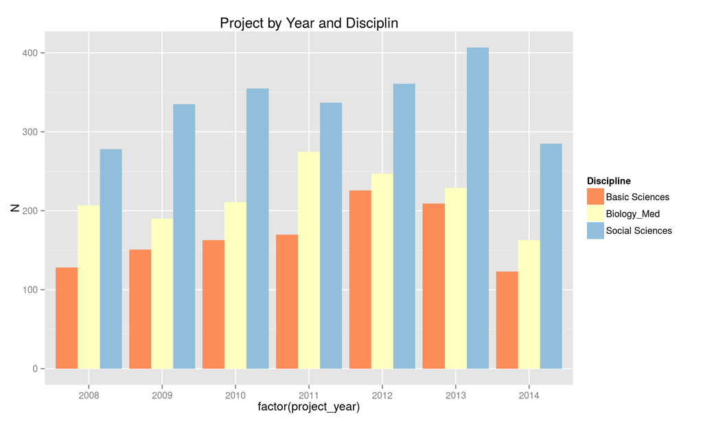

```r
dat.base <- dat[, .N, by = 'project_year,base_disc_name']

ggplot(dat.base, aes(factor(project_year), N)) +
  geom_bar(aes(fill = base_disc_name), stat='identity', position = 'dodge') +
  scale_fill_brewer(palette = 'RdYlBu') +
  labs('title' = 'Project by Year and Disciplin', fill = 'Discipline')
```

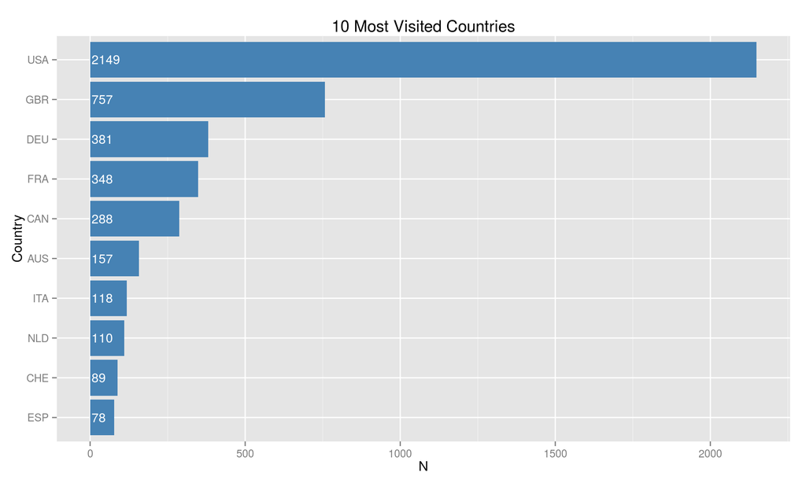

```r
dat.lb <- dat.agg[[2]]
dat.l <- dat.lb[, list(N = sum(N)), by='iso3'][order(N)]

ggplot(subset(dat.l, N > 77), aes(reorder(iso3, N), N)) +
  geom_bar(stat='identity', fill ='steelblue') + coord_flip() +
  geom_text(aes(y = 5, label = N), size = 4,  hjust = 0, color = 'white') +
  labs(title = '10 Most Visited Countries', x = 'Country')
```

The US and the UK are dominating the location where the Swiss post-doc are pursuing their researches, which is confirmed by the following map.

```r
world.map <- readOGR(dsn="data", layer="TM_WORLD_BORDERS_SIMPL-0.3")
```

OGR data source with driver: ESRI Shapefile Source: “data”, layer: “TM_WORLD_BORDERS_SIMPL-0.3” with 246 features and 11 fields Feature type: wkbPolygon with 2 dimensions

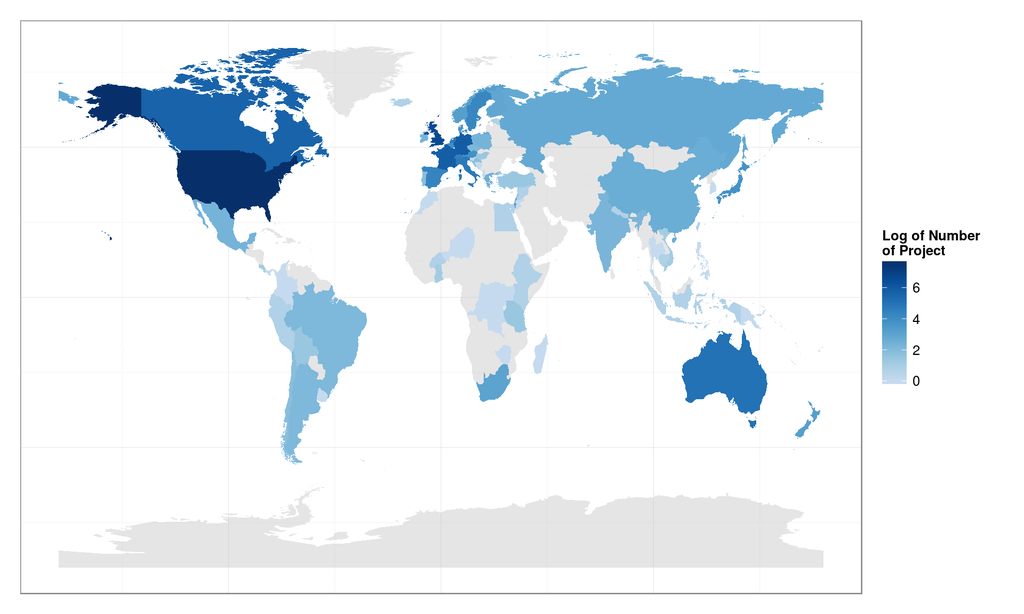

```r
world.ggmap <- fortify(world.map, region = "ISO3")

n <- length(unique(world.ggmap$id))
df <- data.frame(iso3 = unique(world.ggmap$id), growth = 0)

ggplot(df, aes(map_id = iso3)) +
  geom_map(map = world.ggmap, alpha = 0.4, fill = 'grey') +
  geom_map(data = dat.l, aes(fill = log(N)), map = world.ggmap) +
  expand_limits(x = world.ggmap$long, y = world.ggmap$lat) +
  scale_fill_gradientn(
      colours = brewer.pal(9, 'Blues')[c(-1,-2)], guide = "colorbar",
      name = 'Log of Number\nof Project') +
  labs(y = NULL, x = NULL) + theme_bw() +
    theme(axis.line = element_blank(), axis.ticks = element_blank(),
          axis.text = element_blank())
```

Finally, one can note that the number of project are relatively constant and the ranking has not change that much these last years.

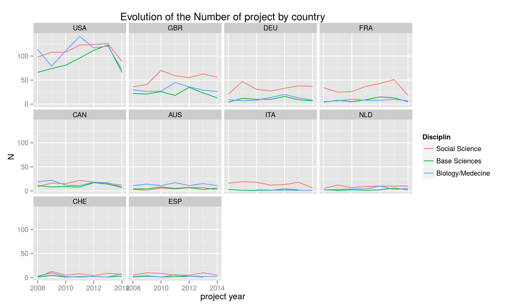

```r
most_country <- subset(dat.l, N > 77)$iso3
dat.lyb <- dat.agg[[1]]
dat.sub <- subset(dat.lyb, iso3 %in% most_country)
dat.sub[, iso3 := factor(iso3, levels = rev(most_country))];

ggplot(dat.sub) + facet_wrap(~iso3) +
  geom_line(aes(project_year, N, color=factor(base_disciplin))) +
  scale_color_discrete(name = 'Disciplin',
    label = c('Social Science', 'Base Sciences', 'Biology/Medecine')) +
  labs(x='project year', title='Evolution of the Number of project by country')
```

## Cities

As previously noted, American and Britisch cities are rulling this ranking. Notice, however, that Canadian cities are perticualary appreciated by the Swiss post-docs.

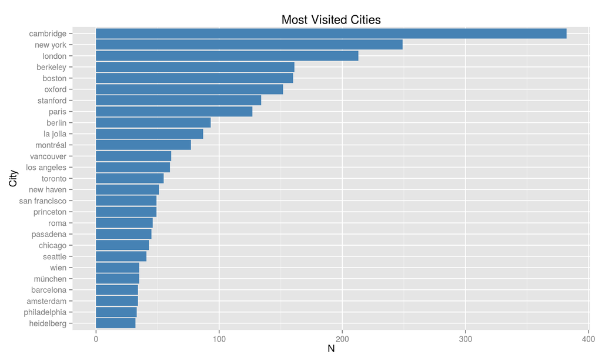

```r
dat.cb <- dat.agg[[4]]
dat.c <- dat.cb[, list(N = sum(N)), by='host_city'][order(N)]

ggplot(subset(dat.c, N > 30), aes(reorder(host_city, N), N)) +
  geom_bar(stat='identity', fill ='steelblue') + coord_flip() +
  labs(x = 'City', title = 'Most Visited Cities')
```

## Conclusion

There are however several remaining questions and other visualizations they might be interesting:

- What if we refine the analysis to the cities and not the country?
- What about the finer information about the disciplins?
- Are there relationship with the time or trends? Especially concerning developping/emerging countries?
- What about statistical analysis?